# Time on Ice Blog Post | University of Denver Sports Analytics

Ryan Rucki, Sam Knapp, & Chris Wall

2025-06-07

## Prompt

A player’s role on a team can change due to trades, injuries, or coaching decisions, often leading to a significant increase or decrease in their average ice time. But how does this affect their performance? In this project, you will use game-by-game and season-level player data to explore the relationship between average ice time and various performance metrics for various different types of players. Your goal is to find some general trends, and to offer a sense of what to expect when a player’s ice time changes.

## Data-sets and Data Cleaning code used for this project:

“players” data: Consists of random names and values such as corsi, primary assists, defensive plays, etc that do not correlate to LA Kings players. After playing with the data set to try and retrieve quantifiable results, it became obvious that this data set did not contain reliable information.

“playerstats” data: Similar to the player’s data explained above, this data set is difficult to work with because it does not have player names, only player_id making it difficult to measure.

“Kings_All” data: Dataset that initially combined all the data we web scraped from Money-Puck covering the 23-24 and 24-25 seasons (playoffs included). This was the groups first attempt at making a combined data set for visualization creation and regression modeling. This dataset was not really used in our final analysis but it certainly helped us build a foundation.

“Kings2” data: This is the data set that we used for most of our regression models and data visualizations. What was unique about this data set was that Ryan was able to create a few df functions that helped standardize values across columns, apply the janitor package to clean names, and then lastly create a column “play_uid” that accurately tracked LA Kings players across the two different seasons. This data set was extremely helpful in creating and understanding what variables impact ice time.

```r
library(tidyverse)
library(dplyr)
library(sportyR)
library(ISAR)
library(hockeyR)
library(ggplot2)
library(readr)
library(janitor)
library(car)
library(forcats)

players <- read_csv("player_game_results.csv")

players1 <- players |>
  group_by(name) |>
  summarise(avgIcetime = mean(timeOnIce)/60)
playerstats <- read_csv("player_on_roster_stats.csv")


#Kings 24-25 Playoffs

Playoffs_2425 <- read_csv("Kings_Playoffs_24-25-1.csv")


#Kings 24-25 Regular Season

Regular_2425 <- read_csv("24-25.regular.csv")



#Kings 23-24 Playoffs

Playoffs_2324 <- read_csv("Kings_Playoffs_23-24.csv")


#Kings 23-24 Regular

Regular_2324 <- read_csv("Kings.Reg.23.24.csv")



# clean
Regular_2425 <- Regular_2425 |>  clean_names()
Playoffs_2425 <- Playoffs_2425 |>  clean_names()
Regular_2324 <- Regular_2324 |>  clean_names()
Playoffs_2324 <- Playoffs_2324 |> clean_names()

# season and context tags
Regular_2425 <- Regular_2425 |>
  mutate(season = "2024-25", context = "Regular")

Playoffs_2425 <- Playoffs_2425 |>
  mutate(season = "2024-25", context = "Playoffs")

Regular_2324 <- Regular_2324 |>
  mutate(season = "2023-24", context = "Regular")

Playoffs_2324 <- Playoffs_2324 |>
  mutate(season = "2023-24", context = "Playoffs")

# calculate performance stats
rename_fields <- function(df) {
  df |>
    rename(
      player_id = player_id,
      name = name,
      pos = pos,
      games_played = games_played,
      icetime = icetime_minutes,
      goals = goals_7,
      xgoals = expected_goals,
      points60 = points_per_60_minutes,
      xgoals60 = expected_goals_per_60_minutes
    ) |>
    mutate(
      goals = as.integer(goals),
      assists = as.integer(assists),
      points = as.integer(points),
      xgoals = as.numeric(xgoals),
      points60 = as.numeric(points60),
      xgoals60 = as.numeric(xgoals60),
      icetime = as.numeric(icetime),
      goals60 = ifelse(icetime > 0, (goals / icetime) * 60, NA_real_)
    ) |>
    select(player_id, name, pos, season, context, games_played, icetime,
           goals, assists, points, xgoals, goals60, points60, xgoals60)
}

# apply function to all datasets
Regular_2425_clean <- rename_fields(Regular_2425)
Playoffs_2425_clean <- rename_fields(Playoffs_2425)
Regular_2324_clean <- rename_fields(Regular_2324)
Playoffs_2324_clean <- rename_fields(Playoffs_2324)

# combine all datasets
Kings_All <- bind_rows(
  Regular_2425_clean,
  Playoffs_2425_clean,
  Regular_2324_clean,
  Playoffs_2324_clean
)

# combined dataset
View(Kings_All)
```

```r
# load, tag, and clean
load_and_prepare <- function(path, season, context) {
  read_csv(path) |>
    mutate(season = season, context = context) |>
    clean_names() |>
    select(
      name, pos, games_played, icetime_minutes, expected_goals, goals_7,
      assists, points, primary_assists, secondary_assist, shifts,
      share_of_possible_icetime, hits, season, context
    )
}

reg_2324   <- load_and_prepare("Kings.Reg.23.24.csv", "2023-24", "Regular")
play_2324  <- load_and_prepare("Kings_Playoffs_23-24.csv", "2023-24", "Playoffs")
reg_2425   <- load_and_prepare("24-25.regular.csv", "2024-25", "Regular")
play_2425  <- load_and_prepare("Kings_Playoffs_24-25-1.csv", "2024-25", "Playoffs")

# numeric variables
standardize_core <- function(df) {
  df |>
    mutate(
      games_played = as.numeric(games_played),
      icetime = as.numeric(icetime_minutes),
      expected_goals = as.numeric(expected_goals),
      goals = as.numeric(goals_7),
      assists = as.numeric(assists),
      points = as.numeric(points),
      primary_assists = as.numeric(primary_assists),
      secondary_assists = as.numeric(secondary_assist),
      shifts = as.numeric(shifts),
      share_of_possible_icetime = as.numeric(share_of_possible_icetime),
      hits = as.numeric(hits),
      name = str_trim(name)
    ) |>
    select(
      name, pos, games_played, icetime, expected_goals, goals, assists,
      points, primary_assists, secondary_assists, shifts,
      share_of_possible_icetime, hits, season, context
    )
}

# standardization
reg_2324   <- standardize_core(reg_2324)
play_2324  <- standardize_core(play_2324)
reg_2425   <- standardize_core(reg_2425)
play_2425  <- standardize_core(play_2425)

# combine datasets
Kings <- bind_rows(reg_2324, play_2324, reg_2425, play_2425)

# player_uid  per-game metric
Kings2 <- Kings |>
  group_by(name) |>
  mutate(player_uid = cur_group_id()) |>
  ungroup() |>
  mutate(icetime_pg = icetime / games_played)
```

## How Ice Time Shapes NHL Performance

Ice time at its core measures how long a player is on the ice during a game, commonly reported in minutes per game or as total minutes across a season. Although on the surface this stat seems simple, the metric explores deeper insights behind player opportunity, trust, and impact.

Ice time is not distributed evenly across an NHL roaster. Coaches allocate ice time strategically and some variables impacting ice-time may unquantifiable. Star forwards might clock 20+ minutes, while fourth-line players or depth defense men log only a fraction of that (4-5 minutes). This uneven distribution can not only detail a players capabilities, it can also expose driving forces behind how a player produces. More chances on ice provide players more opportunities to shoot, assist, pass, and defend. Thus providing players the chance to contribute towards team success.

Yet, the relationship between ice time and performance isn’t always linear. Some players thrive with increased ice time, while others see their efficiency dip. Injuries, trades, or coaching adjustments can shift a player’s role midseason, altering their average ice time and, potentially, their performance outcomes.

That raises an important question: What variables are most important in determining ice time for LA Kings players over the past two seasons? Which LA Kings players are the most intriguing to explore based off of these critical variables in addition to changes in ice time and our own intuition.

In this blog post, we explore this question using recent data from the NHL (via MoneyPuck, & LA Kings data). By utilizing regular season and playoff data, our team looks to discover which variables are the most important in predicting ice time.

To elaborate on that, we decided to create visualizations and re-run regression models based on the variables we thought would be the most intriguing to explore, along with variables that showed confidence in impacting ice time.

## Regression and Logistic Tests

```r
#Basic lm models on Kings_All dataset.
model1 <- lm(icetime ~ points, data = Kings_All)
summary(model1)
```

```
##
## Call:
## lm(formula = icetime ~ points, data = Kings_All)
##
## Residuals:
##     Min      1Q  Median      3Q     Max
## -703.35 -147.64 -103.64   60.66  885.56
##
## Coefficients:
##             Estimate Std. Error t value Pr(>|t|)
## (Intercept)  160.476     40.999   3.914 0.000181 ***
## points        26.665      1.774  15.035  < 2e-16 ***
## ---
## Signif. codes:  0 '***' 0.001 '**' 0.01 '*' 0.05 '.' 0.1 ' ' 1
##
## Residual standard error: 299.8 on 86 degrees of freedom
## Multiple R-squared:  0.7244, Adjusted R-squared:  0.7212
## F-statistic:   226 on 1 and 86 DF,  p-value: < 2.2e-16
```

```r
model2 <- glm(icetime ~ points + goals + assists + xgoals + goals60 + points60 + xgoals60 + games_played + pos + context + season, data = Kings_All)
summary(model2)
```

```
##
## Call:
## glm(formula = icetime ~ points + goals + assists + xgoals + goals60 +
##     points60 + xgoals60 + games_played + pos + context + season,
##     data = Kings_All)
##
## Coefficients: (1 not defined because of singularities)
##                Estimate Std. Error t value Pr(>|t|)
## (Intercept)     -39.533     45.228  -0.874  0.38486
## points           17.296      3.309   5.227  1.5e-06 ***
## goals            -6.308      9.152  -0.689  0.49280
## assists              NA         NA      NA       NA
## xgoals          -21.293      7.367  -2.890  0.00503 **
## goals60          -9.689     38.475  -0.252  0.80186
## points60          8.080     22.782   0.355  0.72383
## xgoals60         -1.633      2.080  -0.785  0.43482
## games_played     14.042      1.166  12.048  < 2e-16 ***
## posD            122.638     38.850   3.157  0.00230 **
## posL             66.698     42.056   1.586  0.11696
## posR             28.970     40.808   0.710  0.47996
## contextRegular  -73.109     45.540  -1.605  0.11261
## season2024-25   -62.619     33.283  -1.881  0.06380 .
## ---
## Signif. codes:  0 '***' 0.001 '**' 0.01 '*' 0.05 '.' 0.1 ' ' 1
##
## (Dispersion parameter for gaussian family taken to be 15569.05)
##
##     Null deviance: 28054154  on 87  degrees of freedom
## Residual deviance:  1167679  on 75  degrees of freedom
## AIC: 1113.1
##
## Number of Fisher Scoring iterations: 2
```

```r
model3 <- glm(icetime ~ points + xgoals + xgoals60 + games_played + pos + context + season, data = Kings_All)
summary(model3)
```

```
##
## Call:
## glm(formula = icetime ~ points + xgoals + xgoals60 + games_played +
##     pos + context + season, data = Kings_All)
##
## Coefficients:
##                Estimate Std. Error t value Pr(>|t|)
## (Intercept)     -30.817     34.790  -0.886  0.37845
## points           16.125      2.063   7.818 2.12e-11 ***
## xgoals          -25.319      5.588  -4.531 2.09e-05 ***
## xgoals60         -1.826      1.967  -0.928  0.35604
## games_played     14.209      1.070  13.278  < 2e-16 ***
## posD            122.089     37.408   3.264  0.00163 **
## posL             60.897     41.119   1.481  0.14264
## posR             30.309     39.981   0.758  0.45068
## contextRegular  -75.571     44.762  -1.688  0.09535 .
## season2024-25   -64.800     32.637  -1.985  0.05061 .
## ---
## Signif. codes:  0 '***' 0.001 '**' 0.01 '*' 0.05 '.' 0.1 ' ' 1
##
## (Dispersion parameter for gaussian family taken to be 15171.88)
##
##     Null deviance: 28054154  on 87  degrees of freedom
## Residual deviance:  1183407  on 78  degrees of freedom
## AIC: 1108.3
##
## Number of Fisher Scoring iterations: 2
```

```r
model_refined <- glm(icetime ~ points + xgoals + games_played, data = Kings_All)
summary(model_refined)
```

```
##
## Call:
## glm(formula = icetime ~ points + xgoals + games_played, data = Kings_All)
##
## Coefficients:
##              Estimate Std. Error t value Pr(>|t|)
## (Intercept)  -16.9204    21.2177  -0.797    0.427
## points        18.0752     2.1749   8.311 1.44e-12 ***
## xgoals       -29.8215     4.9528  -6.021 4.40e-08 ***
## games_played  12.9545     0.7293  17.764  < 2e-16 ***
## ---
## Signif. codes:  0 '***' 0.001 '**' 0.01 '*' 0.05 '.' 0.1 ' ' 1
##
## (Dispersion parameter for gaussian family taken to be 18435.8)
##
##     Null deviance: 28054154  on 87  degrees of freedom
## Residual deviance:  1548608  on 84  degrees of freedom
## AIC: 1120
##
## Number of Fisher Scoring iterations: 2
```

[figure not shown]

```r
Kings_All$predicted_points <- predict(model_refined)

ggplot(Kings_All, aes(x = points, y = predicted_points)) +
  geom_point(color = "steelblue", alpha = 0.7) +
  geom_abline(intercept = 0, slope = 30, color = "red", linetype = "dashed") +
  labs(
    title = "Actual vs Predicted Points",
    x = "Actual Points",
    y = "Predicted Points"
  ) +
  theme_minimal()
```

After running regressions from the “Kings_All” data set, we pivoted and created the Kings2 data, which really let us explore more about these variables. In the Kings_All data, points, xgoals, and games_played seemed to be the most important in explaining ice time. Our team felt that this data set did not allow us to explore more variables that could also be important, yet it was crucial to run regression on Kings_All to further understand ice time.

```r
#Linear Regression Model For Points


glm_data <- Kings2 |>

  filter(games_played >= 10) |>

  drop_na(points, icetime_pg, expected_goals, goals, assists,

          primary_assists, secondary_assists, shifts, share_of_possible_icetime, hits)



# GLM model with all predictors (excluding player name, pos, season, context, player_uid)

model_glm <- glm(points ~ icetime_pg + expected_goals +

                   primary_assists + secondary_assists,

                 data = glm_data, family = gaussian())


# Summary of the model

summary(model_glm)
```

```
##
## Call:
## glm(formula = points ~ icetime_pg + expected_goals + primary_assists +
##     secondary_assists, family = gaussian(), data = glm_data)
##
## Coefficients:
##                   Estimate Std. Error t value Pr(>|t|)
## (Intercept)       -2.08155    1.94302  -1.071    0.290
## icetime_pg         0.05009    0.16393   0.306    0.761
## expected_goals     0.91768    0.08777  10.455 3.91e-13 ***
## primary_assists    0.99517    0.11381   8.744 6.46e-11 ***
## secondary_assists  1.25415    0.13128   9.553 5.52e-12 ***
## ---
## Signif. codes:  0 '***' 0.001 '**' 0.01 '*' 0.05 '.' 0.1 ' ' 1
##
## (Dispersion parameter for gaussian family taken to be 8.22619)
##
##     Null deviance: 16844.96  on 45  degrees of freedom
## Residual deviance:   337.27  on 41  degrees of freedom
## AIC: 234.19
##
## Number of Fisher Scoring iterations: 2
```

```r
vif(model_glm)
```

```
##        icetime_pg    expected_goals   primary_assists secondary_assists
##          2.341137          2.617868          3.625342          3.096160
```

```r
#Does ice time matter more for players who generate more scoring chances?

model_glm_interact <- glm(points ~ icetime_pg * expected_goals +
                            primary_assists + secondary_assists + shifts,
                          data = glm_data,
                          family = gaussian())

summary(model_glm_interact)
```

```
##
## Call:
## glm(formula = points ~ icetime_pg * expected_goals + primary_assists +
##     secondary_assists + shifts, family = gaussian(), data = glm_data)
##
## Coefficients:
##                            Estimate Std. Error t value Pr(>|t|)
## (Intercept)                0.402116   2.666768   0.151    0.881
## icetime_pg                -0.062485   0.238293  -0.262    0.795
## expected_goals             0.421137   0.355935   1.183    0.244
## primary_assists            0.962530   0.118727   8.107 6.81e-10 ***
## secondary_assists          1.189996   0.142548   8.348 3.27e-10 ***
## shifts                    -0.000299   0.001682  -0.178    0.860
## icetime_pg:expected_goals  0.033825   0.022640   1.494    0.143
## ---
## Signif. codes:  0 '***' 0.001 '**' 0.01 '*' 0.05 '.' 0.1 ' ' 1
##
## (Dispersion parameter for gaussian family taken to be 8.028931)
##
##     Null deviance: 16844.96  on 45  degrees of freedom
## Residual deviance:   313.13  on 39  degrees of freedom
## AIC: 234.77
##
## Number of Fisher Scoring iterations: 2
```

```r
#Nonlinearity

model_glm_poly <- glm(points ~ poly(icetime_pg, 2) + expected_goals +
                      primary_assists + secondary_assists + shifts,
                      data = glm_data,
                      family = gaussian())


summary(model_glm_poly)
```

```
##
## Call:
## glm(formula = points ~ poly(icetime_pg, 2) + expected_goals +
##     primary_assists + secondary_assists + shifts, family = gaussian(),
##     data = glm_data)
##
## Coefficients:
##                       Estimate Std. Error t value Pr(>|t|)
## (Intercept)          -0.574686   1.623543  -0.354    0.725
## poly(icetime_pg, 2)1  3.422689   5.293686   0.647    0.522
## poly(icetime_pg, 2)2  3.143043   3.178505   0.989    0.329
## expected_goals        0.954910   0.092559  10.317 1.05e-12 ***
## primary_assists       1.020845   0.116161   8.788 8.69e-11 ***
## secondary_assists     1.247366   0.135851   9.182 2.71e-11 ***
## shifts               -0.001131   0.001568  -0.722    0.475
## ---
## Signif. codes:  0 '***' 0.001 '**' 0.01 '*' 0.05 '.' 0.1 ' ' 1
##
## (Dispersion parameter for gaussian family taken to be 8.280824)
##
##     Null deviance: 16844.96  on 45  degrees of freedom
## Residual deviance:   322.95  on 39  degrees of freedom
## AIC: 236.19
##
## Number of Fisher Scoring iterations: 2
```

```r
library(caret)

#Cross Validation and Fit Model

set.seed(123)

# 5-fold CV
train_control <- trainControl(method = "cv", number = 5)

# Train model
cv_model <- train(points ~ icetime_pg + expected_goals +
                  primary_assists + secondary_assists,
                  data = glm_data,
                  method = "glm",
                  family = "gaussian",
                  trControl = train_control)



# Cross-validated performance
cv_model$results
```

```
##   parameter     RMSE  Rsquared      MAE   RMSESD RsquaredSD     MAESD
## 1      none 3.139098 0.9742735 2.387554 1.206656 0.01349575 0.8351278
```

```r
#Standardized
model_glm_scaled <- glm(points ~ scale(icetime_pg) +
                          scale(expected_goals) +
                          scale(primary_assists) +
                          scale(secondary_assists),
                        data = glm_data,
                        family = gaussian())

summary(model_glm_scaled)
```

```
##
## Call:
## glm(formula = points ~ scale(icetime_pg) + scale(expected_goals) +
##     scale(primary_assists) + scale(secondary_assists), family = gaussian(),
##     data = glm_data)
##
## Coefficients:
##                          Estimate Std. Error t value Pr(>|t|)
## (Intercept)               25.3913     0.4229  60.043  < 2e-16 ***
## scale(icetime_pg)          0.1999     0.6542   0.306    0.761
## scale(expected_goals)      7.2326     0.6918  10.455 3.91e-13 ***
## scale(primary_assists)     7.1184     0.8141   8.744 6.46e-11 ***
## scale(secondary_assists)   7.1869     0.7523   9.553 5.52e-12 ***
## ---
## Signif. codes:  0 '***' 0.001 '**' 0.01 '*' 0.05 '.' 0.1 ' ' 1
##
## (Dispersion parameter for gaussian family taken to be 8.22619)
##
##     Null deviance: 16844.96  on 45  degrees of freedom
## Residual deviance:   337.27  on 41  degrees of freedom
## AIC: 234.19
##
## Number of Fisher Scoring iterations: 2
```

```r
#Points predicted plot
glm_data$predicted_points <- predict(model_glm_scaled)
```

To evaluate how ice time affects player performance, we built a series of regression models using game-by-game and season-level NHL data. After refining the model through multicollinearity checks, interaction testing, and variable standardization, we arrived at a final linear model that predicts player point totals based on expected goals, primary assists, and secondary assists. These three variables were all highly significant, with each one-standard-deviation increase associated with a 7-point boost in season scoring. Surprisingly, average ice time per game was not a significant predictor, suggesting that opportunity alone doesn’t drive production, a player’s quality of offensive involvement is much more impactful. This adds to our argument of trying to analyze players from both a qualitative and quantitative perspective about their value added to the team. The model achieved an R-Squared of 97.4% and performed consistently, confirming its strengths.

```r
#Ice time predicted

model_icetime <- glm(icetime_pg ~ expected_goals + primary_assists +
                       secondary_assists + shifts,
                     data = glm_data,
                     family = gaussian())
vif(model_icetime)
```

```
##    expected_goals   primary_assists secondary_assists            shifts
##          2.441618          3.694859          2.661136          2.657858
```

```r
#simple model
model_icetime_simple <- glm(icetime_pg ~ expected_goals + shifts +
                              primary_assists + secondary_assists,
                            data = glm_data,
                            family = gaussian())

summary(model_icetime_simple)
```

```
##
## Call:
## glm(formula = icetime_pg ~ expected_goals + shifts + primary_assists +
##     secondary_assists, family = gaussian(), data = glm_data)
##
## Coefficients:
##                    Estimate Std. Error t value Pr(>|t|)
## (Intercept)        8.435452   0.838863  10.056 1.25e-12 ***
## expected_goals    -0.157759   0.067406  -2.340  0.02421 *
## shifts             0.004340   0.001027   4.225  0.00013 ***
## primary_assists    0.056170   0.091365   0.615  0.54209
## secondary_assists  0.272882   0.096784   2.819  0.00738 **
## ---
## Signif. codes:  0 '***' 0.001 '**' 0.01 '*' 0.05 '.' 0.1 ' ' 1
##
## (Dispersion parameter for gaussian family taken to be 5.201617)
##
##     Null deviance: 716.68  on 45  degrees of freedom
## Residual deviance: 213.27  on 41  degrees of freedom
## AIC: 213.1
##
## Number of Fisher Scoring iterations: 2
```

```r
model_icetime_refined <- glm(icetime_pg ~ expected_goals + shifts + secondary_assists,
                             data = glm_data,
                             family = gaussian())

summary(model_icetime_refined)
```

```
##
## Call:
## glm(formula = icetime_pg ~ expected_goals + shifts + secondary_assists,
##     family = gaussian(), data = glm_data)
##
## Coefficients:
##                     Estimate Std. Error t value Pr(>|t|)
## (Intercept)        8.3506410  0.8212917  10.168 6.81e-13 ***
## expected_goals    -0.1325354  0.0530838  -2.497  0.01654 *
## shifts             0.0045071  0.0009835   4.583 4.08e-05 ***
## secondary_assists  0.2918996  0.0910261   3.207  0.00257 **
## ---
## Signif. codes:  0 '***' 0.001 '**' 0.01 '*' 0.05 '.' 0.1 ' ' 1
##
## (Dispersion parameter for gaussian family taken to be 5.12458)
##
##     Null deviance: 716.68  on 45  degrees of freedom
## Residual deviance: 215.23  on 42  degrees of freedom
## AIC: 211.52
##
## Number of Fisher Scoring iterations: 2
```

```r
#Polynomial
model_icetime_poly <- glm(icetime_pg ~ expected_goals + poly(shifts, 2) + secondary_assists,
                          data = glm_data,
                          family = gaussian())

summary(model_icetime_poly)
```

```
##
## Call:
## glm(formula = icetime_pg ~ expected_goals + poly(shifts, 2) +
##     secondary_assists, family = gaussian(), data = glm_data)
##
## Coefficients:
##                   Estimate Std. Error t value Pr(>|t|)
## (Intercept)       14.04020    0.71187  19.723  < 2e-16 ***
## expected_goals    -0.10043    0.04640  -2.164  0.03631 *
## poly(shifts, 2)1  18.30875    3.10501   5.897 6.07e-07 ***
## poly(shifts, 2)2   8.17142    2.06271   3.961  0.00029 ***
## secondary_assists  0.18937    0.08251   2.295  0.02692 *
## ---
## Signif. codes:  0 '***' 0.001 '**' 0.01 '*' 0.05 '.' 0.1 ' ' 1
##
## (Dispersion parameter for gaussian family taken to be 3.796424)
##
##     Null deviance: 716.68  on 45  degrees of freedom
## Residual deviance: 155.65  on 41  degrees of freedom
## AIC: 198.62
##
## Number of Fisher Scoring iterations: 2
```

```r
#Cross Validation
set.seed(123)


# 5-fold cross-validation
train_control <- trainControl(method = "cv", number = 5)



# Train using caret
cv_poly_model <- train(icetime_pg ~ expected_goals + poly(shifts, 2) + secondary_assists,
                       data = glm_data,
                       method = "glm",
                       family = "gaussian",
                       trControl = train_control)
# Results
cv_poly_model$results
```

```
##   parameter     RMSE  Rsquared      MAE    RMSESD RsquaredSD     MAESD
## 1      none 1.956063 0.7236941 1.311108 0.8163513  0.2530214 0.3764921
```

```r
#Standardized
model_icetime_scaled <- glm(icetime_pg ~ scale(expected_goals) +
                              poly(scale(shifts), 2) +
                              scale(secondary_assists),
                            data = glm_data,
                            family = gaussian())


summary(model_icetime_scaled)
```

```
##
## Call:
## glm(formula = icetime_pg ~ scale(expected_goals) + poly(scale(shifts),
##     2) + scale(secondary_assists), family = gaussian(), data = glm_data)
##
## Coefficients:
##                          Estimate Std. Error t value Pr(>|t|)
## (Intercept)               14.4527     0.2873  50.308  < 2e-16 ***
## scale(expected_goals)     -0.7916     0.3657  -2.164  0.03631 *
## poly(scale(shifts), 2)1   18.3088     3.1050   5.897 6.07e-07 ***
## poly(scale(shifts), 2)2    8.1714     2.0627   3.961  0.00029 ***
## scale(secondary_assists)   1.0852     0.4728   2.295  0.02692 *
## ---
## Signif. codes:  0 '***' 0.001 '**' 0.01 '*' 0.05 '.' 0.1 ' ' 1
##
## (Dispersion parameter for gaussian family taken to be 3.796424)
##
##     Null deviance: 716.68  on 45  degrees of freedom
## Residual deviance: 155.65  on 41  degrees of freedom
## AIC: 198.62
##
## Number of Fisher Scoring iterations: 2
```

```r
# Plot


glm_data$predicted_icetime <- predict(model_icetime_scaled)
```

To understand what drives a player’s average ice time per game, we built a series of regression models using NHL player data. Our team arrived at a final model that predicts icetime_pg using shifts, secondary assists, and expected goals. The number of shifts had a nonlinear effect, making it the strongest predictor of ice time. A one-standard-deviation increase in secondary assists was associated with a +1.1-minute increase, while expected goals had a small but significant negative effect, suggesting that players who generate high shot quality may be efficient scorers in limited time. The model explained 72% of the variance in ice time (via cross-validation) with a root mean squared error of 1.96 minutes, indicating strong performance and practical predictive utility. These findings suggest that ice time is more influenced by a player’s role and supporting contributions than by primary scoring metrics alone.

## Visualizations

From the regressions a few plots were made:

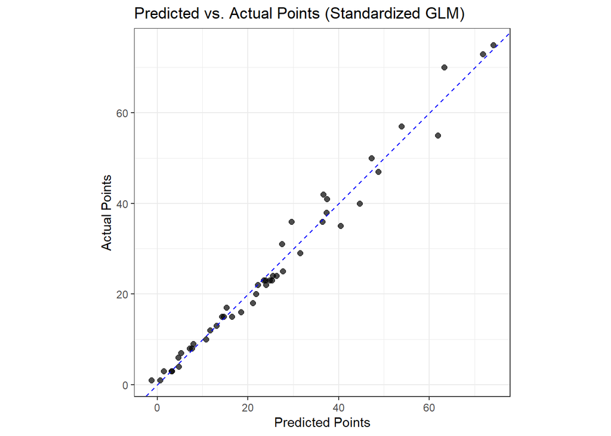

```r
glm_data$predicted_points <- predict(model_glm_scaled)



ggplot(glm_data, aes(x = predicted_points, y = points)) +
  geom_point(size = 2, alpha = 0.7) +
  geom_abline(slope = 1, intercept = 0, linetype = "dashed", color = "blue") +
  labs(
    title = "Predicted vs. Actual Points (Standardized GLM)",
    x = "Predicted Points",
    y = "Actual Points"
  ) +
  theme_bw() +
  coord_equal()
```

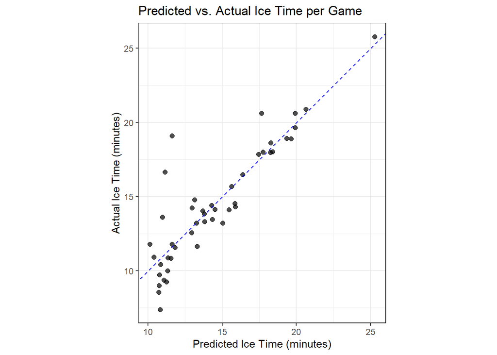

```r
ggplot(glm_data, aes(x = predicted_icetime, y = icetime_pg)) +
  geom_point(size = 2, alpha = 0.7) +
  geom_abline(slope = 1, intercept = 0, color = "blue", linetype = "dashed") +
  labs(
    title = "Predicted vs. Actual Ice Time per Game",
    x = "Predicted Ice Time (minutes)",
    y = "Actual Ice Time (minutes)"
  ) +
  theme_bw() +
  coord_equal()
```

Visually plotting predicted points vs actual along with predicted icetime vs actual we can see how close our data was from an ideal correlation between the two metrics. This provides us confidence in the regression models we decided to run for this project.

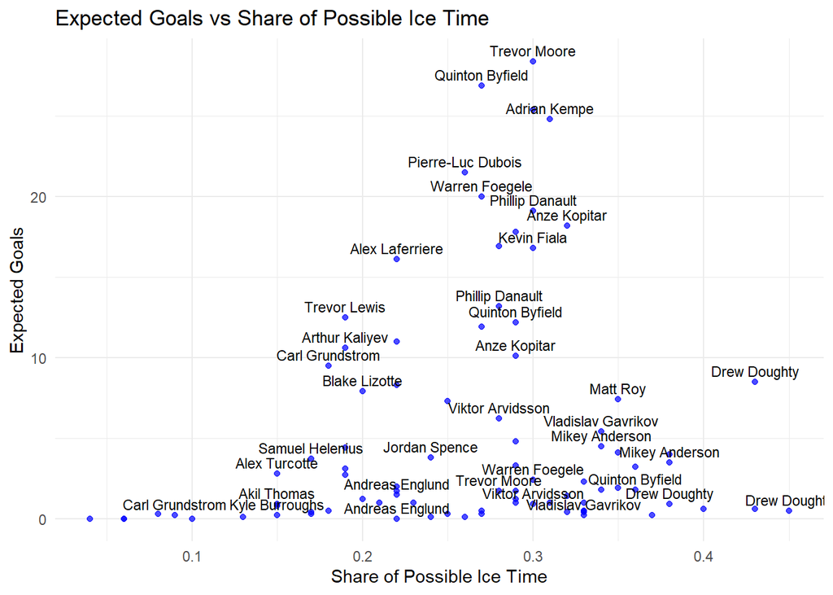

```r
ggplot(Kings2, aes(x = share_of_possible_icetime, y = expected_goals, label = name)) +
  geom_point(color = "blue", alpha = 0.7) +
  geom_text(vjust = -0.5, size = 3, check_overlap = TRUE) +
  labs(
    title = "Expected Goals vs Share of Possible Ice Time",
    x = "Share of Possible Ice Time",
    y = "Expected Goals"
  ) +
  theme_minimal()
```

By making a scatter plot of players’ expected goals against their share of possible ice time, we can see some points of discussion. It’s interesting to see Drew Doughty’s plot points, which hover over the bottom right. Although he holds such a large share of possible ice time, his expected goal numbers make sense. This is because he is a defenseman, so he is obviously not going to score as much as Adrian Kempe or Anze Kopitar. Yet he is such a crucial piece on the defense side of things that he can retain a high share of ice time despite not having a high expected goal statistic time and time.

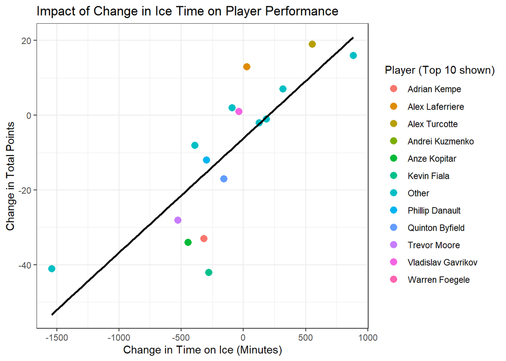

```r
combined <- full_join(
  select(Regular_2324, name, TOI_23 = icetime_minutes, Points_23 = points),
  select(Regular_2425, name, TOI_24 = icetime_minutes, Points_24 = points),
  join_by(name == name)
) %>%
  mutate(
    Delta_TOI = TOI_24 - TOI_23,
    Delta_Points = Points_24 - Points_23)


top_names <- combined %>%
  slice_max(order_by = Points_24, n = 10) %>%
  pull(name)

combined <- combined %>%
  mutate(name_legend = if_else(name %in% top_names, name, "Other"))

ggplot(combined, aes(x = Delta_TOI, y = Delta_Points)) +
  geom_point(aes(color = name_legend), size = 3) +
  geom_smooth(method = "lm", se = FALSE, color = "black") +
  labs(
    title = "Impact of Change in Ice Time on Player Performance",
    x = "Change in Time on Ice (Minutes)",
    y = "Change in Total Points",
    color = "Player (Top 10 shown)"
  ) +
  theme_bw()
```

Exploring Primary Assist across LA Kings players over the past two Seasons:

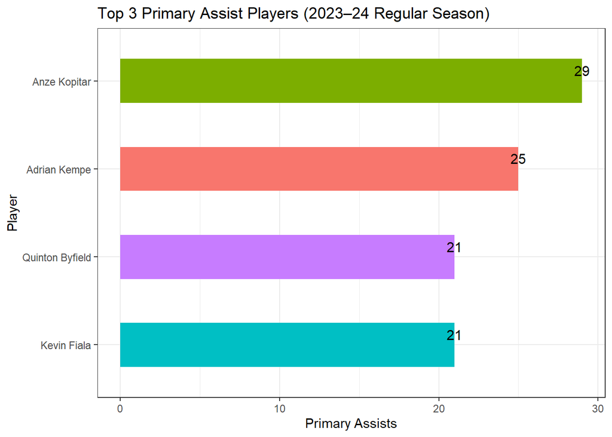

```r
Kings2 |>
  filter(season == "2023-24", context == "Regular") |>
  group_by(name) |>
  summarise(primary = sum(primary_assists, na.rm = TRUE), .groups = "drop") |>
  slice_max(order_by = primary, n = 3) |>
  ggplot(aes(x = reorder(name, primary), y = primary, fill = name)) +
  geom_col(width = 0.5, show.legend = FALSE) +  # Thinner bars
  geom_text(aes(label = primary), vjust = -0.5, size = 4) +  # Add values
  labs(
    title = "Top 3 Primary Assist Players (2023–24 Regular Season)",
    x = "Player",
    y = "Primary Assists"
  ) +
  theme_bw()+
  coord_flip()
```

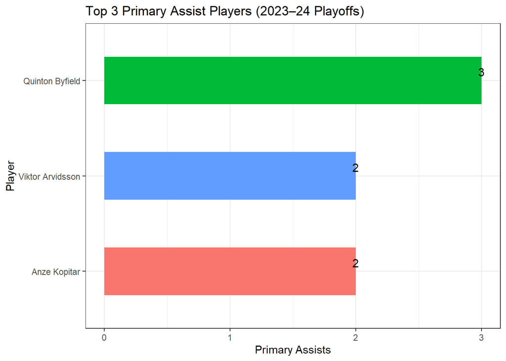

```r
Kings2 |>
  filter(season == "2023-24", context == "Playoffs") |>
  group_by(name) |>
  summarise(primary = sum(primary_assists, na.rm = TRUE), .groups = "drop") |>
  slice_max(order_by = primary, n = 3) |>
  ggplot(aes(x = reorder(name, primary), y = primary, fill = name)) +
  geom_col(width = 0.5, show.legend = FALSE) +
  geom_text(aes(label = primary), vjust = -0.5, size = 4) +
  labs(
    title = "Top 3 Primary Assist Players (2023–24 Playoffs)",
    x = "Player",
    y = "Primary Assists"
  ) +
  theme_bw() +
  coord_flip()
```

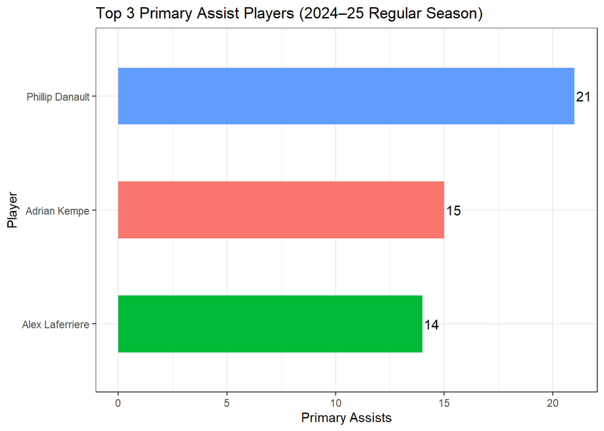

```r
Kings2 |>
  filter(season == "2024-25", context == "Regular") |>
  group_by(name) |>
  summarise(primary = sum(primary_assists, na.rm = TRUE), .groups = "drop") |>
  slice_max(order_by = primary, n = 3) |>
  ggplot(aes(x = reorder(name, primary), y = primary, fill = name)) +
  geom_col(width = 0.5, show.legend = FALSE) +
  geom_text(aes(label = primary), hjust = -0.1, size = 4) +
  labs(
    title = "Top 3 Primary Assist Players (2024–25 Regular Season)",
    x = "Player",
    y = "Primary Assists"
  ) +
  coord_flip() +
  theme_bw()
```

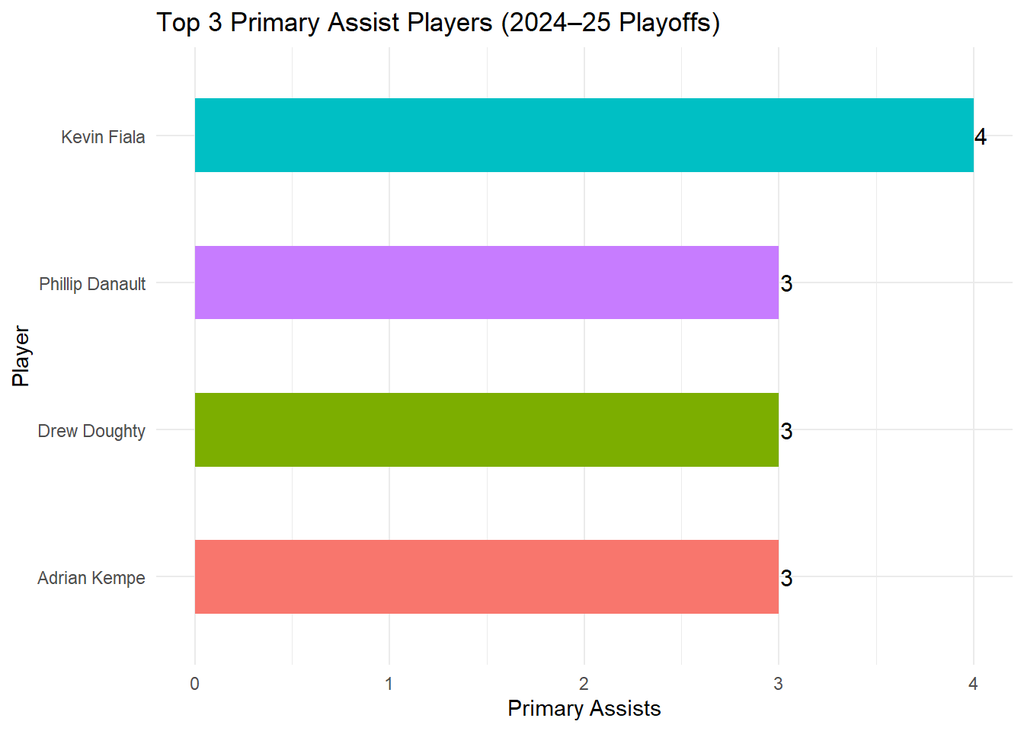

```r
Kings2 |>
  filter(season == "2024-25", context == "Playoffs") |>
  group_by(name) |>
  summarise(primary = sum(primary_assists, na.rm = TRUE), .groups = "drop") |>
  slice_max(order_by = primary, n = 3) |>
  ggplot(aes(x = reorder(name, primary), y = primary, fill = name)) +
  geom_col(width = 0.5, show.legend = FALSE) +
  geom_text(aes(label = primary), hjust = -0.1, size = 4) +
  labs(
    title = "Top 3 Primary Assist Players (2024–25 Playoffs)",
    x = "Player",
    y = "Primary Assists"
  ) +
  coord_flip() +
  theme_minimal()
```

Watching the leading primary assist-makers shift from regular to playoff season is rather intriguing. Anze Kopitar, led the Kings throughout the entirety of the 23-24 regular season. Then once the playoffs came, Anze Kopitar fell to 3rd. What is even more interesting is how Kevin Fiala took first place in most primary assists in this year’s playoffs despite not even taking the top 3 assists within the season!

Exploring Secondary Assist across LA Kings players over the past two Seasons:

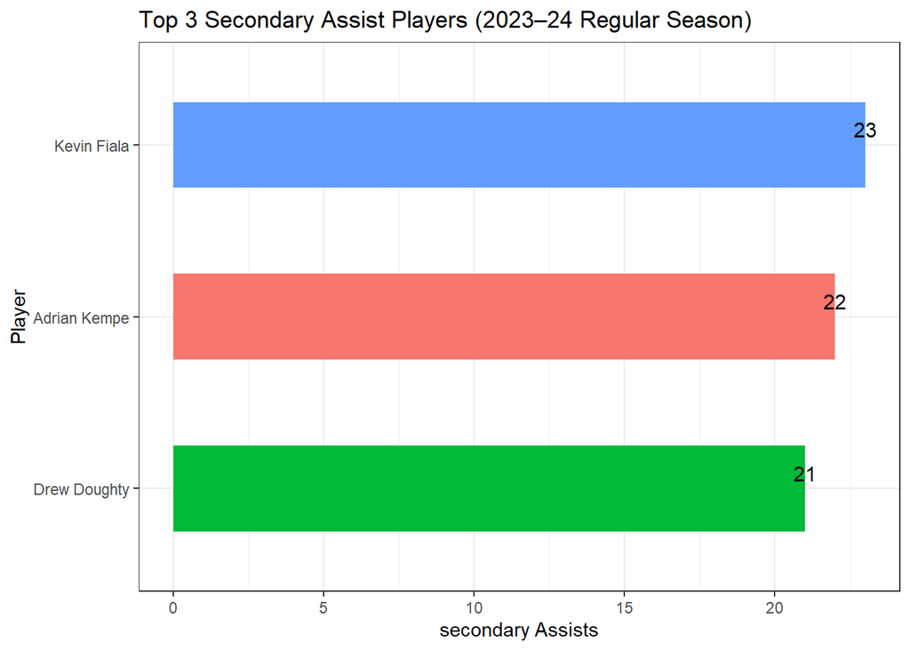

```r
Kings2 |>
  filter(season == "2023-24", context == "Regular") |>
  group_by(name) |>
  summarise(secondary = sum(secondary_assists, na.rm = TRUE), .groups = "drop") |>
  slice_max(order_by = secondary, n = 3) |>
  ggplot(aes(x = reorder(name, secondary), y = secondary, fill = name)) +
  geom_col(width = 0.5, show.legend = FALSE) +  # Thinner bars
  geom_text(aes(label = secondary), vjust = -0.5, size = 4) +  # Add values
  labs(
    title = "Top 3 Secondary Assist Players (2023–24 Regular Season)",
    x = "Player",
    y = "secondary Assists"
  ) +
  theme_bw()+
  coord_flip()
```

[figure not shown]

```r
Kings2 |>
  filter(season == "2023-24", context == "Playoffs") |>
  group_by(name) |>
  summarise(secondary = sum(secondary_assists, na.rm = TRUE), .groups = "drop") |>
  slice_max(order_by = secondary, n = 3) |>
  ggplot(aes(x = reorder(name, secondary), y = secondary, fill = name)) +
  geom_col(width = 0.5, show.legend = FALSE) +
  geom_text(aes(label = secondary), vjust = -0.5, size = 4) +
  labs(
    title = "Top 3 Primary Assist Players (2023–24 Playoffs)",
    x = "Player",
    y = "Primary Assists"
  ) +
  theme_bw() +
  coord_flip()
```

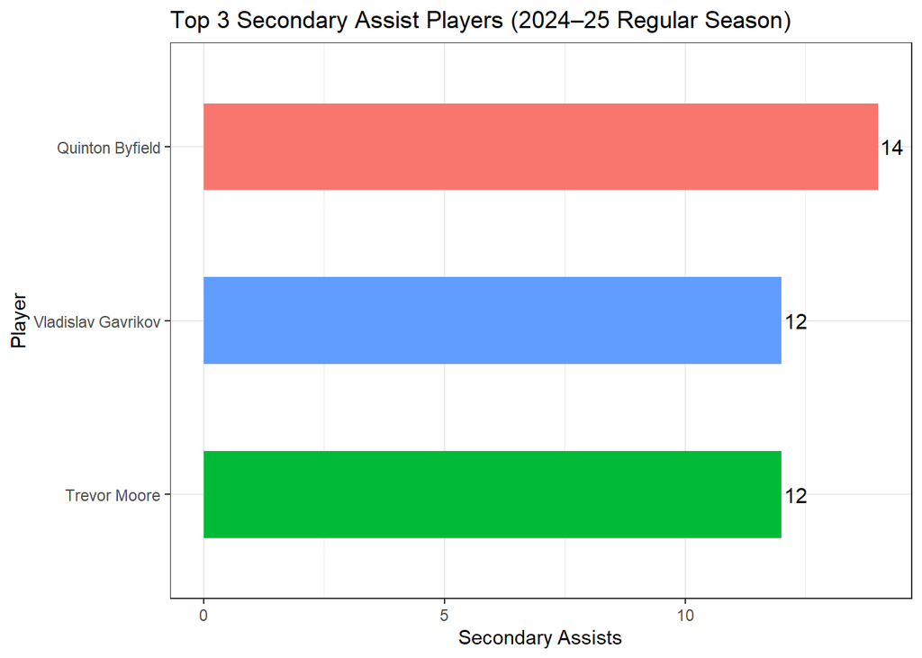

```r
Kings2 |>
  filter(season == "2024-25", context == "Regular") |>
  group_by(name) |>
  summarise(secondary = sum(secondary_assists, na.rm = TRUE), .groups = "drop") |>
  slice_max(order_by = secondary, n = 3) |>
  ggplot(aes(x = reorder(name, secondary), y = secondary, fill = name)) +
  geom_col(width = 0.5, show.legend = FALSE) +
  geom_text(aes(label = secondary), hjust = -0.1, size = 4) +
  labs(
    title = "Top 3 Secondary Assist Players (2024–25 Regular Season)",
    x = "Player",
    y = "Secondary Assists"
  ) +
  coord_flip() +
  theme_bw()
```

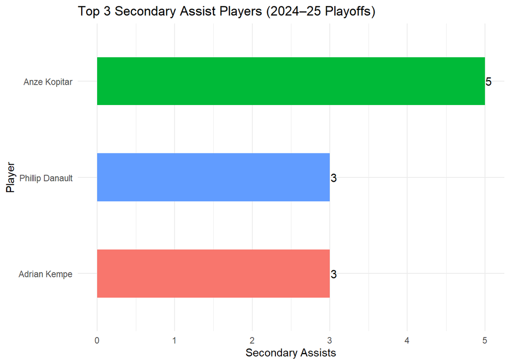

```r
Kings2 |>
  filter(season == "2024-25", context == "Playoffs") |>
  group_by(name) |>
  summarise(secondary = sum(secondary_assists, na.rm = TRUE), .groups = "drop") |>
  slice_max(order_by = secondary, n = 3) |>
  ggplot(aes(x = reorder(name, secondary), y = secondary, fill = name)) +
  geom_col(width = 0.5, show.legend = FALSE) +
  geom_text(aes(label = secondary), hjust = -0.1, size = 4) +
  labs(
    title = "Top 3 Secondary Assist Players (2024–25 Playoffs)",
    x = "Player",
    y = "Secondary Assists"
  ) +
  coord_flip() +
  theme_minimal()
```

Although secondary assists may seem like a niche statistic with limited insight, our regression models indicate that they are actually a strong predictor of ice time. That’s why I wanted to examine how this variable played out over the last two seasons. What stands out during the 2023–24 playoffs is the number of players who recorded at least one secondary assist.

Given that the LA Kings have now been eliminated by the Oilers in three consecutive playoff runs, it’s especially interesting to see how assist metrics were affected in a postseason where the team’s playoff hopes were once again cut short by the same opponent.

Looking at individual players, it’s encouraging to see Anze Kopitar rise in the ranks during the 2024–25 playoffs. While primary and secondary assists don’t tell the full story, they offer a meaningful starting point for analyzing how specific contributions on the ice relate to overall ice time and ultimately, player impact.

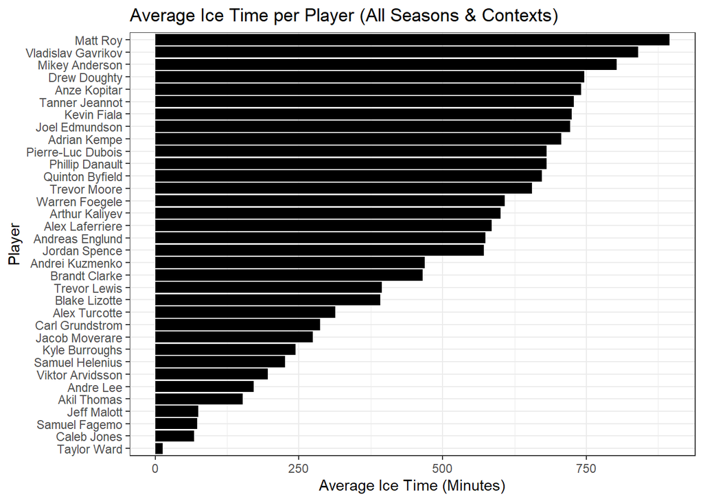

```r
Kings2 %>%
  group_by(player_uid, name) %>%
  summarise(avg_icetime = mean(icetime, na.rm = TRUE), .groups = "drop") %>%
  arrange(desc(avg_icetime)) %>%
  ggplot(aes(x = reorder(name, avg_icetime), y = avg_icetime)) +
  geom_col(fill = "black") +
  coord_flip() +
  labs(
    title = "Average Ice Time per Player (All Seasons & Contexts)",
    x = "Player",
    y = "Average Ice Time (Minutes)"
  ) +
  theme_bw()
```